## Exercise 6.8

**In this exercise, we will generate simulated data, and will then use this data to perform best subset selection.**

1. **Use the `rnorm()` function to generate a predictor X of length n = 100, as well as a noise vector of length n = 100.**

```r
set.seed(1)
X <- rnorm(100)
noise <- rnorm(100)
```

2. **Generate a response vector $Y$ of length $n = 100$ according to the model $Y = \beta_{0} + \beta_{1} X_{1} + \beta_{2}X_{2} + \beta_{3}X_{3}$, where $\beta_{0}$, $\beta_{1}$, $\beta_{2}$, and $\beta_{3}$ are constants of your choice.**

```r
Y <- 3 + 1*X + 4*X^2 - 1*X^3 + noise
```

3. **Use the `regsubsets()` function to perform best subset selection in order to choose the best model containing the predictors $X, X_{2},\ldots,X_{10}$. What is the best model obtained according to $C_{p}$, $BIC$, and adjusted $R^{2}$? Show some plots to provide evidence for your answer, and report the coefficients of the best model obtained. Note you will need to use the `data.frame()` function to create a single data set containing both X and Y.**

```r
require(leaps)
```

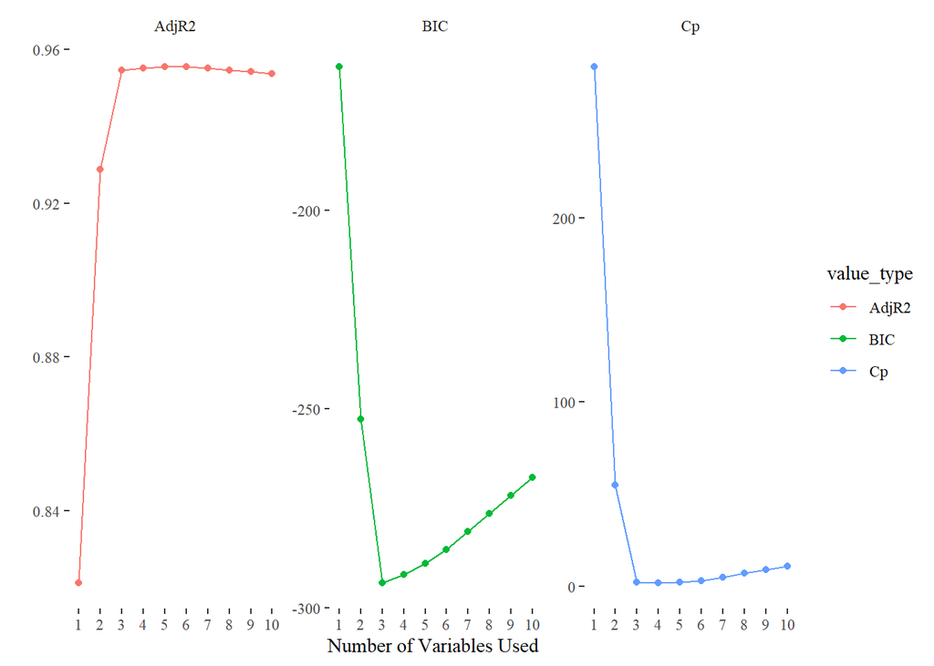

```r
df <- data.frame(Y, X)
fit <- regsubsets(Y ~ poly(X, 10), data = df, nvmax = 10)
fit_summary <- summary(fit)
require(tidyverse);require(ggplot2);require(ggthemes);
data_frame(Cp = fit_summary$cp,
BIC = fit_summary$bic,
AdjR2 = fit_summary$adjr2) %>%
mutate(id = row_number()) %>%
gather(value_type, value, -id) %>%
ggplot(aes(id, value, col = value_type)) +
geom_line() + geom_point() + ylab('') + xlab('Number of Variables Used') +
facet_wrap(~ value_type, scales = 'free') +
theme_tufte() + scale_x_continuous(breaks = 1:10)
```

4. **Repeat (c), using forward stepwise selection and also using backwards stepwise selection. How does your answer compare to the results in (c)?**

```r
require(caret)
model_back <- train(Y ~ poly(X, 10), data = df,
                    method = 'glmStepAIC', direction = 'backward',
                    trace = 0,
               trControl = trainControl(method = 'none', verboseIter = FALSE))

postResample(predict(model_back, df), df$Y)
```

```
##      RMSE  Rsquared       MAE
## 0.9314956 0.9569843 0.7488821
```

```r
summary(model_back$finalModel)
```

```
##
## Call:
## NULL
##
## Deviance Residuals:
##     Min       1Q   Median       3Q      Max
## -1.8914  -0.5860  -0.1516   0.5892   2.1794
##
## Coefficients:
##                 Estimate Std. Error t value Pr(>|t|)
## (Intercept)      6.10265    0.09557  63.856  < 2e-16 ***
## `poly(X, 10)1`  -7.19295    0.95569  -7.526 2.96e-11 ***
## `poly(X, 10)2`  40.74405    0.95569  42.633  < 2e-16 ***
## `poly(X, 10)3` -14.70908    0.95569 -15.391  < 2e-16 ***
## `poly(X, 10)5`   1.48019    0.95569   1.549    0.125
## ---
## Signif. codes:  0 '***' 0.001 '**' 0.01 '*' 0.05 '.' 0.1 ' ' 1
##
## (Dispersion parameter for gaussian family taken to be 0.9133516)
##
##     Null deviance: 2017.132  on 99  degrees of freedom
## Residual deviance:   86.768  on 95  degrees of freedom
## AIC: 281.59
##
## Number of Fisher Scoring iterations: 2
```

```r
x_poly <- poly(df$X, 10)

colnames(x_poly) <- paste0('poly', 1:10)
model_forw <- train(y = Y, x = x_poly,
                    method = 'glmStepAIC', direction = 'forward',
                    trace = 0,
               trControl = trainControl(method = 'none', verboseIter = FALSE))

postResample(predict(model_forw, data.frame(x_poly)), df$Y)
```

```
##      RMSE  Rsquared       MAE
## 0.9314956 0.9569843 0.7488821
```

```r
summary(model_forw$finalModel)
```

```
##
## Call:
## NULL
##
## Deviance Residuals:
##     Min       1Q   Median       3Q      Max
## -1.8914  -0.5860  -0.1516   0.5892   2.1794
##
## Coefficients:
##              Estimate Std. Error t value Pr(>|t|)
## (Intercept)   6.10265    0.09557  63.856  < 2e-16 ***
## poly2        40.74405    0.95569  42.633  < 2e-16 ***
## poly3       -14.70908    0.95569 -15.391  < 2e-16 ***
## poly1        -7.19295    0.95569  -7.526 2.96e-11 ***
## poly5         1.48019    0.95569   1.549    0.125
## ---
## Signif. codes:  0 '***' 0.001 '**' 0.01 '*' 0.05 '.' 0.1 ' ' 1
##
## (Dispersion parameter for gaussian family taken to be 0.9133516)
##
##     Null deviance: 2017.132  on 99  degrees of freedom
## Residual deviance:   86.768  on 95  degrees of freedom
## AIC: 281.59
##
## Number of Fisher Scoring iterations: 2
```

Both the backwards and forwards models agree.

5. **Now fit a lasso model to the simulated data, again using X, X2,…,X10 as predictors. Use cross-validation to select the optimal value of $\lambda$. Create plots of the cross-validation error as a function of $\lambda$. Report the resulting coefficient estimates, and discuss the results obtained.**

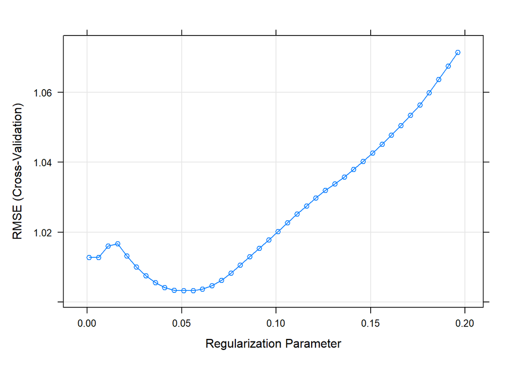

```r
lasso_model <- train(Y ~ poly(X, 10), data = df,
                     method = 'glmnet',
                     trControl = trainControl(method = 'cv', number = 10),
                     tuneGrid = expand.grid(alpha = 1,
                                            lambda = seq(0.001, 0.2, by = 0.005)))

plot(lasso_model)
```

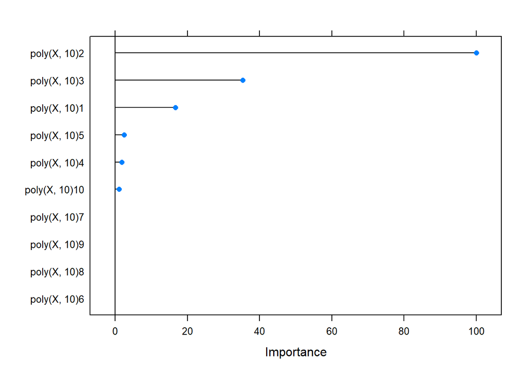

```r
plot(varImp(lasso_model))
```

```r
coef(lasso_model$finalModel, lasso_model$bestTune$lambda)
```

```
## 11 x 1 sparse Matrix of class "dgCMatrix"
##                        s1
## (Intercept)     6.1026472
## poly(X, 10)1   -6.6829512
## poly(X, 10)2   40.2340466
## poly(X, 10)3  -14.1990830
## poly(X, 10)4    0.7470950
## poly(X, 10)5    0.9701884
## poly(X, 10)6    .
## poly(X, 10)7    .
## poly(X, 10)8    .
## poly(X, 10)9    .
## poly(X, 10)10  -0.4412295
```

```r
postResample(predict(lasso_model, df), df$Y)
```

```
##      RMSE  Rsquared       MAE
## 0.9265197 0.9577192 0.7566424
```

The lasso model overestimated the amount of predictors needed, which could be due to only using hte RSS model.

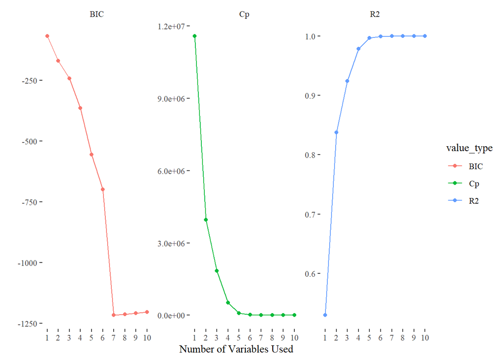

```r
Y_7 <- 3 + 8*X^7 + noise
df_2 <- data_frame(Y_7 = Y_7, X = df[,-1])

fit <- regsubsets(Y_7 ~ poly(X, 10), data = df_2, nvmax = 10)

fit_summary <- summary(fit)

data_frame(Cp = fit_summary$cp,
           BIC = fit_summary$bic,
           R2 = fit_summary$adjr2) %>%
    mutate(id = row_number()) %>%
    gather(value_type, value, -id) %>%
    ggplot(aes(id, value, col = value_type)) +
    geom_line() + geom_point() + ylab('') + xlab('Number of Variables Used') +
    facet_wrap(~ value_type, scales = 'free') +
    theme_tufte() + scale_x_continuous(breaks = 1:10)
```

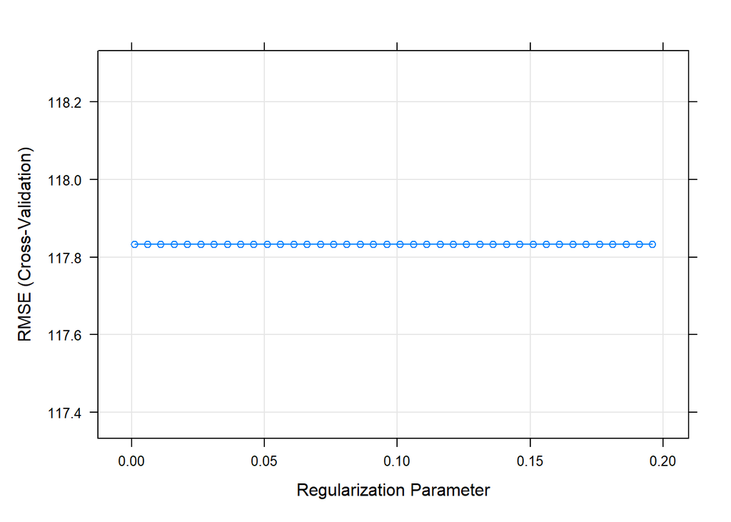

```r
lasso_y7_model <- train(Y_7 ~ poly(X, 10), data = df_2,
                        method = 'glmnet',
                        trControl = trainControl(method = 'cv', number = 5),
                        tuneGrid = expand.grid(alpha = 1,
                                               lambda = seq(0.001, 0.2, by = 0.005)))

plot(lasso_y7_model)
```

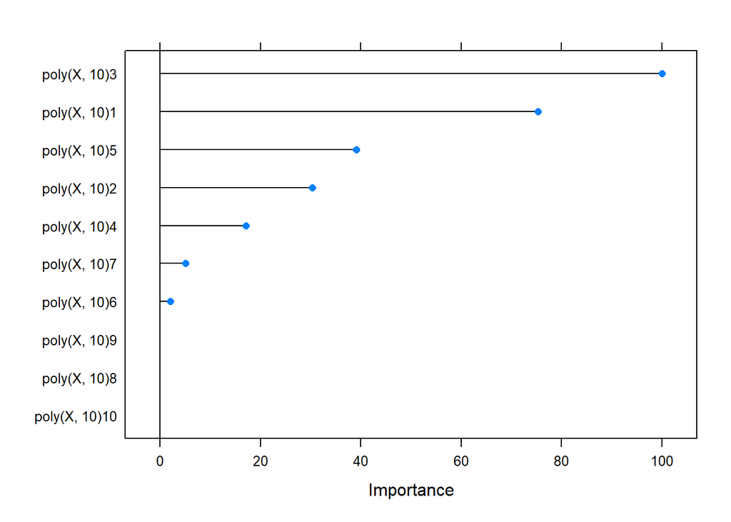

```r
plot(varImp(lasso_y7_model))
```

```r
coef(lasso_y7_model$finalModel, lasso_y7_model$bestTune$lambda)
```

```
## 11 x 1 sparse Matrix of class "dgCMatrix"
##                       s1
## (Intercept)     36.72505
## poly(X, 10)1  2630.24239
## poly(X, 10)2  1059.42846
## poly(X, 10)3  3491.14380
## poly(X, 10)4   597.14287
## poly(X, 10)5  1363.96802
## poly(X, 10)6    70.93052
## poly(X, 10)7   177.79560
## poly(X, 10)8     .
## poly(X, 10)9     .
## poly(X, 10)10    .
```

```r
postResample(predict(lasso_y7_model, df_2), df_2$Y_7)
```

```
##       RMSE   Rsquared        MAE
## 14.2854376  0.9996164  4.9531386
```